# EDA-IMDb

```python
import pandas as pd
df = pd.read_csv(r"imdb_top_250_fixed.csv")
df
```

|  | Rank | Title | Year | Rating | Votes | Runtime | Genre | Content Rating | URL |
| --- | --- | --- | --- | --- | --- | --- | --- | --- | --- |
| 0 | 1 | The Shawshank Redemption | 1994 | 9.3 | 3152846 | 2h 22m | Drama | R | https://www.imdb.com/title/tt0111161/ |
| 1 | 2 | The Godfather | 1972 | 9.2 | 2200213 | 2h 55m | Crime, Drama | R | https://www.imdb.com/title/tt0068646/ |
| 2 | 3 | The Dark Knight | 2008 | 9.1 | 3129006 | 2h 32m | Action, Crime, Drama | PG-13 | https://www.imdb.com/title/tt0468569/ |
| 3 | 4 | The Godfather Part II | 1974 | 9.0 | 1478972 | 3h 22m | Crime, Drama | R | https://www.imdb.com/title/tt0071562/ |
| 4 | 5 | 12 Angry Men | 1957 | 9.0 | 971922 | 1h 36m | Crime, Drama | Approved | https://www.imdb.com/title/tt0050083/ |
| ... | ... | ... | ... | ... | ... | ... | ... | ... | ... |
| 245 | 246 | To Be or Not to Be | 1942 | 8.1 | 49289 | 1h 39m | Comedy, Romance, War | Approved | https://www.imdb.com/title/tt0035446/ |
| 246 | 247 | Gangs of Wasseypur | 2012 | 8.2 | 112893 | 5h 21m | Action, Comedy, Crime | Not Rated | https://www.imdb.com/title/tt1954470/ |
| 247 | 248 | The Grapes of Wrath | 1940 | 8.1 | 107694 | 2h 9m | Drama | Approved | https://www.imdb.com/title/tt0032551/ |
| 248 | 249 | Drishyam | 2015 | 8.2 | 107113 | 2h 43m | Crime, Drama, Mystery | Not Rated | https://www.imdb.com/title/tt4430212/ |
| 249 | 250 | Laapataa Ladies | 2023 | 8.3 | 58162 | 2h 2m | Comedy, Drama | TV-14 | https://www.imdb.com/title/tt21626284/ |

250 rows × 9 columns

```python
df.shape
```

```
(250, 9)
```

```python
df.columns
```

```
Index(['Rank', 'Title', 'Year', 'Rating', 'Votes', 'Runtime', 'Genre',
       'Content Rating', 'URL'],
      dtype='object')
```

```python
df.info()
```

```
<class 'pandas.core.frame.DataFrame'>
RangeIndex: 250 entries, 0 to 249
Data columns (total 9 columns):
 #   Column          Non-Null Count  Dtype
---  ------          --------------  -----
 0   Rank            250 non-null    int64
 1   Title           250 non-null    object
 2   Year            250 non-null    int64
 3   Rating          250 non-null    float64
 4   Votes           250 non-null    int64
 5   Runtime         250 non-null    object
 6   Genre           250 non-null    object
 7   Content Rating  245 non-null    object
 8   URL             250 non-null    object
dtypes: float64(1), int64(3), object(5)
memory usage: 17.7+ KB
```

```python
df.head()
```

|  | Rank | Title | Year | Rating | Votes | Runtime | Genre | Content Rating | URL |
| --- | --- | --- | --- | --- | --- | --- | --- | --- | --- |
| 0 | 1 | The Shawshank Redemption | 1994 | 9.3 | 3152846 | 2h 22m | Drama | R | https://www.imdb.com/title/tt0111161/ |
| 1 | 2 | The Godfather | 1972 | 9.2 | 2200213 | 2h 55m | Crime, Drama | R | https://www.imdb.com/title/tt0068646/ |
| 2 | 3 | The Dark Knight | 2008 | 9.1 | 3129006 | 2h 32m | Action, Crime, Drama | PG-13 | https://www.imdb.com/title/tt0468569/ |
| 3 | 4 | The Godfather Part II | 1974 | 9.0 | 1478972 | 3h 22m | Crime, Drama | R | https://www.imdb.com/title/tt0071562/ |
| 4 | 5 | 12 Angry Men | 1957 | 9.0 | 971922 | 1h 36m | Crime, Drama | Approved | https://www.imdb.com/title/tt0050083/ |

```python
df.tail()
```

|  | Rank | Title | Year | Rating | Votes | Runtime | Genre | Content Rating | URL |
| --- | --- | --- | --- | --- | --- | --- | --- | --- | --- |
| 245 | 246 | To Be or Not to Be | 1942 | 8.1 | 49289 | 1h 39m | Comedy, Romance, War | Approved | https://www.imdb.com/title/tt0035446/ |
| 246 | 247 | Gangs of Wasseypur | 2012 | 8.2 | 112893 | 5h 21m | Action, Comedy, Crime | Not Rated | https://www.imdb.com/title/tt1954470/ |
| 247 | 248 | The Grapes of Wrath | 1940 | 8.1 | 107694 | 2h 9m | Drama | Approved | https://www.imdb.com/title/tt0032551/ |
| 248 | 249 | Drishyam | 2015 | 8.2 | 107113 | 2h 43m | Crime, Drama, Mystery | Not Rated | https://www.imdb.com/title/tt4430212/ |
| 249 | 250 | Laapataa Ladies | 2023 | 8.3 | 58162 | 2h 2m | Comedy, Drama | TV-14 | https://www.imdb.com/title/tt21626284/ |

```python
df.isnull().sum()
```

```
Rank              0
Title             0
Year              0
Rating            0
Votes             0
Runtime           0
Genre             0
Content Rating    5
URL               0
dtype: int64
```

```python
df["Rating"].value_counts()
```

```
Rating
8.1    73
8.2    55
8.3    37
8.4    27
8.5    24
8.6    14
8.8     6
8.7     5
9.0     4
9.2     1
8.9     1
9.1     1
9.3     1
8.0     1
Name: count, dtype: int64
```

```python
df["Content Rating"].value_counts()
```

```
Content Rating
R            103
PG            37
PG-13         34
Not Rated     23
Approved      22
G             18
Passed         6
NC-17          1
TV-14          1
Name: count, dtype: int64
```

```python
df["Votes"].value_counts()
```

```
Votes
3152846    1
2200213    1
3129006    1
1478972    1
971922     1
          ..
49289      1
112893     1
107694     1
107113     1
58162      1
Name: count, Length: 250, dtype: int64
```

```python
df["Genre"].value_counts()
```

```
Genre
Drama                           15
Crime, Drama                    14
Crime, Drama, Mystery           10
Animation, Adventure, Comedy     9
Biography, Drama, History        8
                                ..
Drama, Fantasy                   1
Horror                           1
Drama, Romance, Thriller         1
Comedy, Romance, War             1
Action, Comedy, Crime            1
Name: count, Length: 105, dtype: int64
```

```python
full_label_mapping = {'Restricted': 'Restricted',
    'Parental': 'Parental Guidance Suggested',
    'General': 'General Audience',
    'Not': 'Not Rated',
    'No': 'No Children Under 17',
    'R': 'Restricted',
    'PG-13': 'Parents Strongly Cautioned',
    'PG': 'Parental Guidance Suggested',
    'Approved': 'General Audience',
    'G': 'General Audience',
    'Passed': 'General Audience',
    'NC-17': 'No Children Under 17'
}

df['Content Rating'] = df['Content Rating'].map(full_label_mapping).fillna('Not Rated')

df['Content Rating'].value_counts()
```

```
Content Rating
Restricted                     103
General Audience                46
Parental Guidance Suggested     37
Parents Strongly Cautioned      34
Not Rated                       29
No Children Under 17             1
Name: count, dtype: int64
```

```python
df["Content Rating"].isnull().sum()
```

```
np.int64(0)
```

```python
df.isnull().sum()
```

```
Rank              0
Title             0
Year              0
Rating            0
Votes             0
Runtime           0
Genre             0
Content Rating    0
URL               0
dtype: int64
```

```python
def convert_runtime(time_str):
    try:
        hours = 0
        minutes = 0
        if 'h' in time_str:
            parts = time_str.split('h')
            hours = int(parts[0])
            if 'm' in parts[1]:
                minutes = int(parts[1].replace('m', '').strip())
        elif 'm' in time_str:
            minutes = int(time_str.replace('m', '').strip())
        return (hours * 60) + minutes
    except:
        return None

df['Runtime_Mins'] = df['Runtime'].apply(convert_runtime)
```

```python
df
```

|  | Rank | Title | Year | Rating | Votes | Runtime | Genre | Content Rating | URL | Runtime_Mins |
| --- | --- | --- | --- | --- | --- | --- | --- | --- | --- | --- |
| 0 | 1 | The Shawshank Redemption | 1994 | 9.3 | 3152846 | 2h 22m | Drama | Restricted | https://www.imdb.com/title/tt0111161/ | 142 |
| 1 | 2 | The Godfather | 1972 | 9.2 | 2200213 | 2h 55m | Crime, Drama | Restricted | https://www.imdb.com/title/tt0068646/ | 175 |
| 2 | 3 | The Dark Knight | 2008 | 9.1 | 3129006 | 2h 32m | Action, Crime, Drama | Parents Strongly Cautioned | https://www.imdb.com/title/tt0468569/ | 152 |
| 3 | 4 | The Godfather Part II | 1974 | 9.0 | 1478972 | 3h 22m | Crime, Drama | Restricted | https://www.imdb.com/title/tt0071562/ | 202 |
| 4 | 5 | 12 Angry Men | 1957 | 9.0 | 971922 | 1h 36m | Crime, Drama | General Audience | https://www.imdb.com/title/tt0050083/ | 96 |
| ... | ... | ... | ... | ... | ... | ... | ... | ... | ... | ... |
| 245 | 246 | To Be or Not to Be | 1942 | 8.1 | 49289 | 1h 39m | Comedy, Romance, War | General Audience | https://www.imdb.com/title/tt0035446/ | 99 |
| 246 | 247 | Gangs of Wasseypur | 2012 | 8.2 | 112893 | 5h 21m | Action, Comedy, Crime | Not Rated | https://www.imdb.com/title/tt1954470/ | 321 |
| 247 | 248 | The Grapes of Wrath | 1940 | 8.1 | 107694 | 2h 9m | Drama | General Audience | https://www.imdb.com/title/tt0032551/ | 129 |
| 248 | 249 | Drishyam | 2015 | 8.2 | 107113 | 2h 43m | Crime, Drama, Mystery | Not Rated | https://www.imdb.com/title/tt4430212/ | 163 |
| 249 | 250 | Laapataa Ladies | 2023 | 8.3 | 58162 | 2h 2m | Comedy, Drama | Not Rated | https://www.imdb.com/title/tt21626284/ | 122 |

250 rows × 10 columns

```python
df.info()
```

```
<class 'pandas.core.frame.DataFrame'>
RangeIndex: 250 entries, 0 to 249
Data columns (total 10 columns):
 #   Column          Non-Null Count  Dtype
---  ------          --------------  -----
 0   Rank            250 non-null    int64
 1   Title           250 non-null    object
 2   Year            250 non-null    int64
 3   Rating          250 non-null    float64
 4   Votes           250 non-null    int64
 5   Runtime         250 non-null    object
 6   Genre           250 non-null    object
 7   Content Rating  250 non-null    object
 8   URL             250 non-null    object
 9   Runtime_Mins    250 non-null    int64
dtypes: float64(1), int64(4), object(5)
memory usage: 19.7+ KB
```

```python
df["Year"]=pd.to_numeric(df["Year"],errors="coerce")
```

```python
df
```

|  | Rank | Title | Year | Rating | Votes | Runtime | Genre | Content Rating | URL | Runtime_Mins |
| --- | --- | --- | --- | --- | --- | --- | --- | --- | --- | --- |
| 0 | 1 | The Shawshank Redemption | 1994 | 9.3 | 3152846 | 2h 22m | Drama | Restricted | https://www.imdb.com/title/tt0111161/ | 142 |
| 1 | 2 | The Godfather | 1972 | 9.2 | 2200213 | 2h 55m | Crime, Drama | Restricted | https://www.imdb.com/title/tt0068646/ | 175 |
| 2 | 3 | The Dark Knight | 2008 | 9.1 | 3129006 | 2h 32m | Action, Crime, Drama | Parents Strongly Cautioned | https://www.imdb.com/title/tt0468569/ | 152 |
| 3 | 4 | The Godfather Part II | 1974 | 9.0 | 1478972 | 3h 22m | Crime, Drama | Restricted | https://www.imdb.com/title/tt0071562/ | 202 |
| 4 | 5 | 12 Angry Men | 1957 | 9.0 | 971922 | 1h 36m | Crime, Drama | General Audience | https://www.imdb.com/title/tt0050083/ | 96 |
| ... | ... | ... | ... | ... | ... | ... | ... | ... | ... | ... |
| 245 | 246 | To Be or Not to Be | 1942 | 8.1 | 49289 | 1h 39m | Comedy, Romance, War | General Audience | https://www.imdb.com/title/tt0035446/ | 99 |
| 246 | 247 | Gangs of Wasseypur | 2012 | 8.2 | 112893 | 5h 21m | Action, Comedy, Crime | Not Rated | https://www.imdb.com/title/tt1954470/ | 321 |
| 247 | 248 | The Grapes of Wrath | 1940 | 8.1 | 107694 | 2h 9m | Drama | General Audience | https://www.imdb.com/title/tt0032551/ | 129 |
| 248 | 249 | Drishyam | 2015 | 8.2 | 107113 | 2h 43m | Crime, Drama, Mystery | Not Rated | https://www.imdb.com/title/tt4430212/ | 163 |
| 249 | 250 | Laapataa Ladies | 2023 | 8.3 | 58162 | 2h 2m | Comedy, Drama | Not Rated | https://www.imdb.com/title/tt21626284/ | 122 |

250 rows × 10 columns

```python
df["Genre"].value_counts()
```

```
Genre
Drama                           15
Crime, Drama                    14
Crime, Drama, Mystery           10
Animation, Adventure, Comedy     9
Biography, Drama, History        8
                                ..
Drama, Fantasy                   1
Horror                           1
Drama, Romance, Thriller         1
Comedy, Romance, War             1
Action, Comedy, Crime            1
Name: count, Length: 105, dtype: int64
```

```python
df["Votes"]=df["Votes"].astype(str).str.replace(',','')
```

```python
df["Title"]=df["Title"].str.strip()
```

```python
long_movies = df[df["Runtime_Mins"]>180]
```

```python
import numpy as np
```

```python
df[(df['Year'] < 1920) | (df['Year'] > 2026)]
```

|  | Rank | Title | Year | Rating | Votes | Runtime | Genre | Content Rating | URL | Runtime_Mins |
| --- | --- | --- | --- | --- | --- | --- | --- | --- | --- | --- |

```python
df["Year"].value_counts()
```

```
Year
1995    8
2003    7
2004    7
1999    6
2019    6
       ..
1925    1
1978    1
1926    1
1949    1
1928    1
Name: count, Length: 86, dtype: int64
```

```python
import pandas as pd
df1 = pd.read_csv(r"cleaned_IMDb_data.csv")
df1
```

|  | Rank | Title | Year | Rating | Votes | Votes_log | Runtime_Mins | Runtime_Period | Genre | Content Rating | URL | Decade |
| --- | --- | --- | --- | --- | --- | --- | --- | --- | --- | --- | --- | --- |
| 0 | 1 | The Shawshank Redemption | 1994 | 9.3 | 3150928 | 14.96 | 142 | Medium | Drama | Restricted | https://www.imdb.com/title/tt0111161/ | 1990 |
| 1 | 2 | The Godfather | 1972 | 9.2 | 2198804 | 14.60 | 175 | Long | Crime, Drama | Restricted | https://www.imdb.com/title/tt0068646/ | 1970 |
| 2 | 3 | The Dark Knight | 2008 | 9.1 | 3126599 | 14.96 | 152 | Long | Action, Crime, Drama | Parents Strongly Cautioned | https://www.imdb.com/title/tt0468569/ | 2000 |
| 3 | 4 | The Godfather Part II | 1974 | 9.0 | 1478111 | 14.21 | 202 | Long | Crime, Drama | Restricted | https://www.imdb.com/title/tt0071562/ | 1970 |
| 4 | 5 | 12 Angry Men | 1957 | 9.0 | 971121 | 13.79 | 96 | Medium | Crime, Drama | General Audience | https://www.imdb.com/title/tt0050083/ | 1950 |
| ... | ... | ... | ... | ... | ... | ... | ... | ... | ... | ... | ... | ... |
| 245 | 246 | Gangs of Wasseypur | 2012 | 8.2 | 112799 | 11.63 | 321 | Long | Action, Comedy, Crime | Not Rated | https://www.imdb.com/title/tt1954470/ | 2010 |
| 246 | 247 | To Be or Not to Be | 1942 | 8.1 | 49242 | 10.80 | 99 | Medium | Comedy, Romance, War | General Audience | https://www.imdb.com/title/tt0035446/ | 1940 |
| 247 | 248 | The Grapes of Wrath | 1940 | 8.1 | 107652 | 11.59 | 129 | Medium | Drama | General Audience | https://www.imdb.com/title/tt0032551/ | 1940 |
| 248 | 249 | Drishyam | 2015 | 8.2 | 107011 | 11.58 | 163 | Long | Crime, Drama, Mystery | Not Rated | https://www.imdb.com/title/tt4430212/ | 2010 |
| 249 | 250 | Soorarai Pottru | 2020 | 8.6 | 131136 | 11.78 | 153 | Long | Drama | Not Rated | https://www.imdb.com/title/tt10189514/ | 2020 |

250 rows × 12 columns

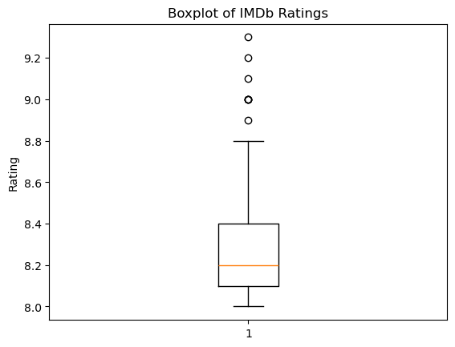

```python
import matplotlib.pyplot as plt

plt.figure()
plt.boxplot(df1['Rating'])
plt.title('Boxplot of IMDb Ratings')
plt.ylabel('Rating')
plt.show()
```

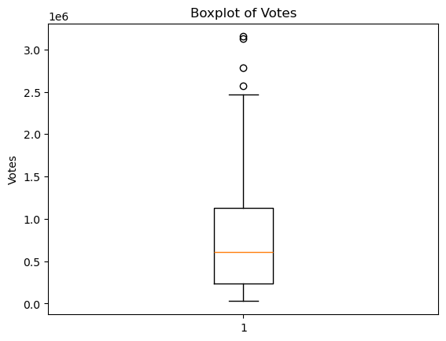

```python
plt.figure()
plt.boxplot(df1['Votes'])
plt.title('Boxplot of Votes')
plt.ylabel('Votes')
plt.show()
```

```python
df1['Votes'] = (
    df1['Votes']
    .astype(str)
    .str.replace(',', '', regex=False)
    .str.replace('None', '', regex=False)
    .str.replace('nan', '', regex=False)
    .str.strip()
)

df1['Votes'] = pd.to_numeric(df1['Votes'], errors='coerce')
```

```python
df1['Votes'].dtype
```

```
dtype('int64')
```

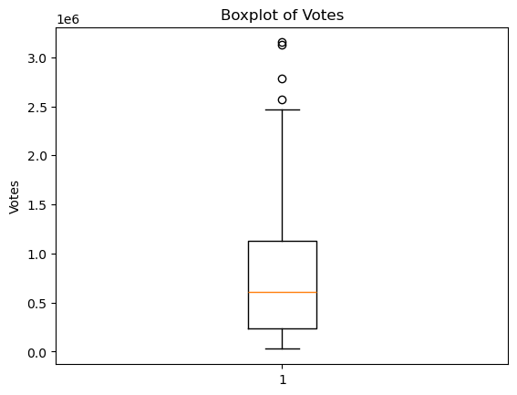

```python
import matplotlib.pyplot as plt

plt.figure()
plt.boxplot(df1['Votes'])
plt.title('Boxplot of Votes')
plt.ylabel('Votes')
plt.show()
```

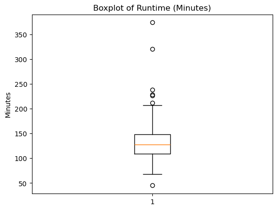

```python
plt.figure()
plt.boxplot(df1['Runtime_Mins'])
plt.title('Boxplot of Runtime (Minutes)')
plt.ylabel('Minutes')
plt.show()
```

```python
df1[(df1['Runtime_Mins'] < 60) | (df1['Runtime_Mins'] > 300)]
```

|  | Rank | Title | Year | Rating | Votes | Votes_log | Runtime_Mins | Runtime_Period | Genre | Content Rating | URL | Decade |
| --- | --- | --- | --- | --- | --- | --- | --- | --- | --- | --- | --- | --- |
| 160 | 161 | La meglio gioventù | 2003 | 8.4 | 27472 | 10.22 | 374 | Long | Drama, Romance | Restricted | https://www.imdb.com/title/tt0346336/ | 2000 |
| 204 | 205 | Sherlock Jr. | 1924 | 8.1 | 64828 | 11.08 | 45 | Short | Action, Comedy, Romance | General Audience | https://www.imdb.com/title/tt0015324/ | 1920 |
| 245 | 246 | Gangs of Wasseypur | 2012 | 8.2 | 112799 | 11.63 | 321 | Long | Action, Comedy, Crime | Not Rated | https://www.imdb.com/title/tt1954470/ | 2010 |

```python
# Check duplicates based on Title + Year
duplicate_rows = df1[df1.duplicated(subset=['Title', 'Year'], keep=False)]
duplicate_rows
```

|  | Rank | Title | Year | Rating | Votes | Votes_log | Runtime_Mins | Runtime_Period | Genre | Content Rating | URL | Decade |
| --- | --- | --- | --- | --- | --- | --- | --- | --- | --- | --- | --- | --- |

```python
df1.shape
```

```
(250, 12)
```

```python
df1.duplicated(subset=['Title', 'Year']).sum()  # should be 0
```

```
np.int64(0)
```

```python
df1.isna().sum()
```

```
Rank              0
Title             0
Year              0
Rating            0
Votes             0
Votes_log         0
Runtime_Mins      0
Runtime_Period    0
Genre             0
Content Rating    0
URL               0
Decade            0
dtype: int64
```

```python
def runtime_bucket(x):
    if x<90:
        return "Short"
    elif x<= 150:
        return "Medium"
    else:
        return "Long"
df1["Runtime_Period"]=df1["Runtime_Mins"].apply(runtime_bucket)
```

```python
import numpy as np
```

```python
df1["Votes_log"]=np.log1p(df1["Votes"])
df1["Votes_log"]=round(df1["Votes_log"],2)
```

```python
df1["Decade"]=(df1["Year"]//10)* 10
```

```python
df1
```

|  | Rank | Title | Year | Rating | Votes | Votes_log | Runtime_Mins | Runtime_Period | Genre | Content Rating | URL | Decade |
| --- | --- | --- | --- | --- | --- | --- | --- | --- | --- | --- | --- | --- |
| 0 | 1 | The Shawshank Redemption | 1994 | 9.3 | 3150928 | 14.96 | 142 | Medium | Drama | Restricted | https://www.imdb.com/title/tt0111161/ | 1990 |
| 1 | 2 | The Godfather | 1972 | 9.2 | 2198804 | 14.60 | 175 | Long | Crime, Drama | Restricted | https://www.imdb.com/title/tt0068646/ | 1970 |
| 2 | 3 | The Dark Knight | 2008 | 9.1 | 3126599 | 14.96 | 152 | Long | Action, Crime, Drama | Parents Strongly Cautioned | https://www.imdb.com/title/tt0468569/ | 2000 |
| 3 | 4 | The Godfather Part II | 1974 | 9.0 | 1478111 | 14.21 | 202 | Long | Crime, Drama | Restricted | https://www.imdb.com/title/tt0071562/ | 1970 |
| 4 | 5 | 12 Angry Men | 1957 | 9.0 | 971121 | 13.79 | 96 | Medium | Crime, Drama | General Audience | https://www.imdb.com/title/tt0050083/ | 1950 |
| ... | ... | ... | ... | ... | ... | ... | ... | ... | ... | ... | ... | ... |
| 245 | 246 | Gangs of Wasseypur | 2012 | 8.2 | 112799 | 11.63 | 321 | Long | Action, Comedy, Crime | Not Rated | https://www.imdb.com/title/tt1954470/ | 2010 |
| 246 | 247 | To Be or Not to Be | 1942 | 8.1 | 49242 | 10.80 | 99 | Medium | Comedy, Romance, War | General Audience | https://www.imdb.com/title/tt0035446/ | 1940 |
| 247 | 248 | The Grapes of Wrath | 1940 | 8.1 | 107652 | 11.59 | 129 | Medium | Drama | General Audience | https://www.imdb.com/title/tt0032551/ | 1940 |
| 248 | 249 | Drishyam | 2015 | 8.2 | 107011 | 11.58 | 163 | Long | Crime, Drama, Mystery | Not Rated | https://www.imdb.com/title/tt4430212/ | 2010 |
| 249 | 250 | Soorarai Pottru | 2020 | 8.6 | 131136 | 11.78 | 153 | Long | Drama | Not Rated | https://www.imdb.com/title/tt10189514/ | 2020 |

250 rows × 12 columns

```python
df1 = pd.read_csv(r"cleaned_IMDb_data.csv")
df1
```

|  | Rank | Title | Year | Rating | Votes | Votes_log | Runtime_Mins | Runtime_Period | Genre | Content Rating | URL | Decade |
| --- | --- | --- | --- | --- | --- | --- | --- | --- | --- | --- | --- | --- |
| 0 | 1 | The Shawshank Redemption | 1994 | 9.3 | 3150928 | 14.96 | 142 | Medium | Drama | Restricted | https://www.imdb.com/title/tt0111161/ | 1990 |
| 1 | 2 | The Godfather | 1972 | 9.2 | 2198804 | 14.60 | 175 | Long | Crime, Drama | Restricted | https://www.imdb.com/title/tt0068646/ | 1970 |
| 2 | 3 | The Dark Knight | 2008 | 9.1 | 3126599 | 14.96 | 152 | Long | Action, Crime, Drama | Parents Strongly Cautioned | https://www.imdb.com/title/tt0468569/ | 2000 |
| 3 | 4 | The Godfather Part II | 1974 | 9.0 | 1478111 | 14.21 | 202 | Long | Crime, Drama | Restricted | https://www.imdb.com/title/tt0071562/ | 1970 |
| 4 | 5 | 12 Angry Men | 1957 | 9.0 | 971121 | 13.79 | 96 | Medium | Crime, Drama | General Audience | https://www.imdb.com/title/tt0050083/ | 1950 |
| ... | ... | ... | ... | ... | ... | ... | ... | ... | ... | ... | ... | ... |
| 245 | 246 | Gangs of Wasseypur | 2012 | 8.2 | 112799 | 11.63 | 321 | Long | Action, Comedy, Crime | Not Rated | https://www.imdb.com/title/tt1954470/ | 2010 |
| 246 | 247 | To Be or Not to Be | 1942 | 8.1 | 49242 | 10.80 | 99 | Medium | Comedy, Romance, War | General Audience | https://www.imdb.com/title/tt0035446/ | 1940 |
| 247 | 248 | The Grapes of Wrath | 1940 | 8.1 | 107652 | 11.59 | 129 | Medium | Drama | General Audience | https://www.imdb.com/title/tt0032551/ | 1940 |
| 248 | 249 | Drishyam | 2015 | 8.2 | 107011 | 11.58 | 163 | Long | Crime, Drama, Mystery | Not Rated | https://www.imdb.com/title/tt4430212/ | 2010 |
| 249 | 250 | Soorarai Pottru | 2020 | 8.6 | 131136 | 11.78 | 153 | Long | Drama | Not Rated | https://www.imdb.com/title/tt10189514/ | 2020 |

250 rows × 12 columns

```python
df.groupby("Year")["Rating"].mean()
```

```
Year
1921    8.200
1924    8.100
1925    8.100
1926    8.100
1927    8.200
        ...
2021    8.350
2022    8.200
2023    8.425
2024    8.300
2025    8.300
Name: Rating, Length: 86, dtype: float64
```

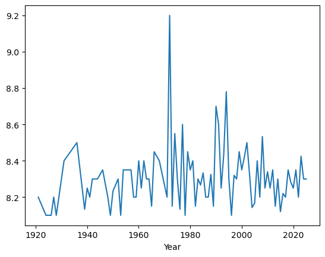

```python
df.groupby("Year")["Rating"].mean().plot()
```

# UNIVARIATE ANLYSIS

```python
import matplotlib.pyplot as plt
import seaborn as sns
import pandas as pd
```

### 1.Rating Distribution

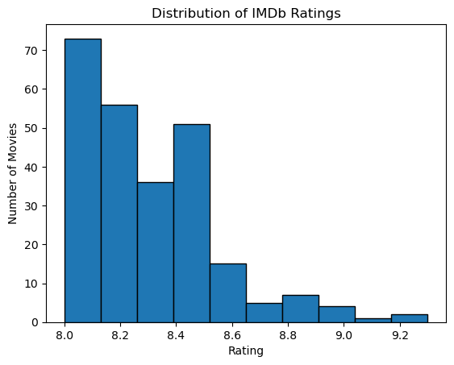

```python
plt.hist(df1['Rating'], bins=10, edgecolor='k')
plt.title('Distribution of IMDb Ratings')
plt.xlabel('Rating')
plt.ylabel('Number of Movies')
plt.show()
```

- Interpretation:

Few movies below 8.0 → Top 250 naturally favors high-rated films

## 2.Runtime distribution

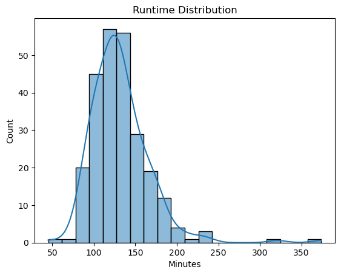

```python
sns.histplot(df1['Runtime_Mins'], bins=20, kde=True)
plt.title('Runtime Distribution')
plt.xlabel('Minutes')
plt.show()
```

- Interpretation:

Most movies are between 90–150 mins

Long epics (>180 mins) exist but are rare

Shorter films (<90 mins) are mostly animated or classics

## 3. Votes

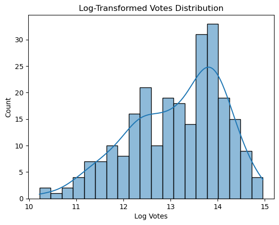

```python
sns.histplot(df1['Votes_log'], bins=20, kde=True)
plt.title('Log-Transformed Votes Distribution')
plt.xlabel('Log Votes')
plt.show()
```

- Interpretation:

Log transformation balances skew

Shows spread from low-vote cult classics to blockbusters

Important for weighting rating reliability

## 4.Decade Distribution

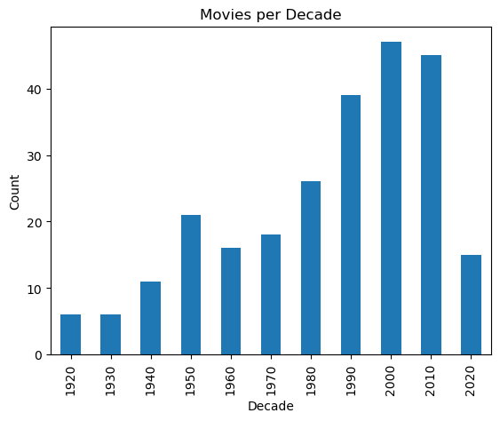

```python
df1['Decade'].value_counts().sort_index().plot(kind='bar')
plt.title('Movies per Decade')
plt.ylabel('Count')
plt.show()
```

### * Interpretation:

Most Top 250 movies are from 1970s–2010s

Indicates bias towards modern, widely viewed films

Older classics (<1960s) are fewer

## 5.Genre Counts

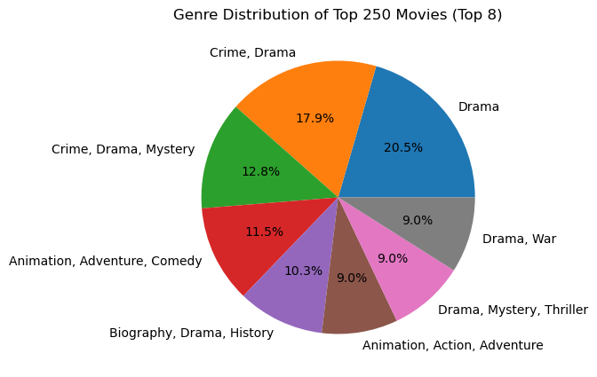

```python
df1["Genre"].value_counts().head(8).plot(kind='pie', autopct='%1.1f%%', figsize=(5,5))
plt.title('Genre Distribution of Top 250 Movies (Top 8)')
plt.ylabel('')
plt.show()
```

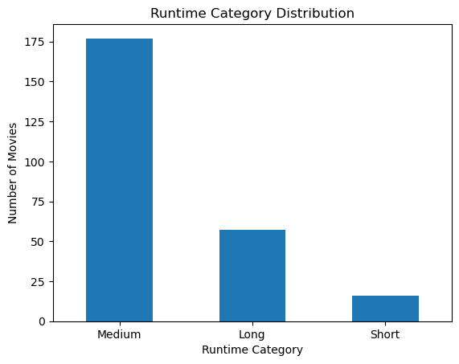

```python
plt.figure()
df1['Runtime_Period'].value_counts().plot(kind='bar')
plt.xlabel('Runtime Category')
plt.ylabel('Number of Movies')
plt.title('Runtime Category Distribution')
plt.xticks(rotation=0,ha="center")
plt.show()
```

```python
round(df1["Rating"].describe(),1)
```

```
count    250.0
mean       8.3
std        0.2
min        8.0
25%        8.1
50%        8.2
75%        8.4
max        9.3
Name: Rating, dtype: float64
```

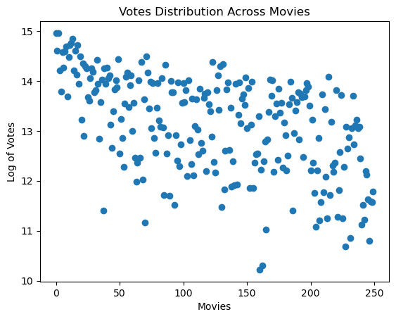

```python
plt.figure()
plt.scatter(range(len(df1['Votes_log'])), df1['Votes_log'])
plt.xlabel('Movies')
plt.ylabel('Log of Votes')
plt.title('Votes Distribution Across Movies')
plt.show()
```

# BIVARIATE ANALYSIS

## Content Rating vs Rating vs Votes_log

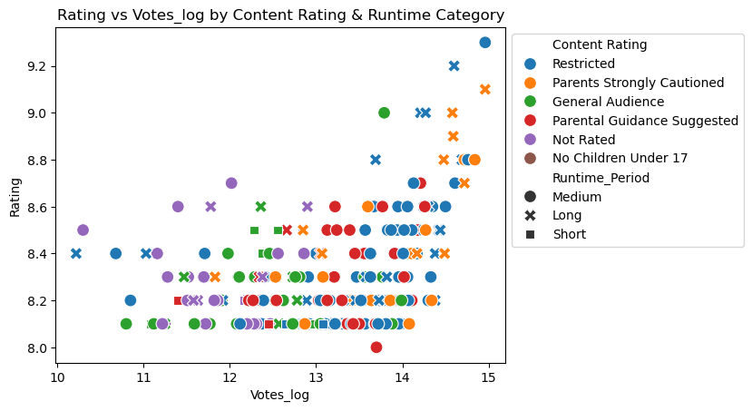

```python
sns.scatterplot(data=df1, x='Votes_log', y='Rating', hue='Content Rating', style='Runtime_Period', s=100)
plt.title('Rating vs Votes_log by Content Rating & Runtime Category')
plt.legend(bbox_to_anchor=(1, 1), loc='upper left')
plt.show()
```

### * Interpretation

R-rated films are more dispersed → niche / critically acclaimed

## Does a higher number of votes correlate with a higher rating?

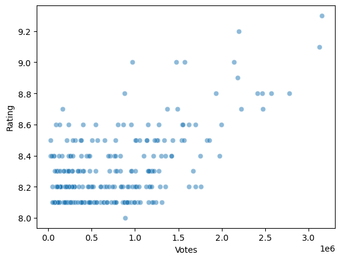

```python
sns.scatterplot(x='Votes', y='Rating', data=df1, alpha=0.5)
```

### *Interpretation:

While most top-rated movies have high votes, there isn't always a linear relationship. Some "cult classics" have very high ratings but fewer votes compared to massive blockbusters.

## Are longer movies rated more highly?

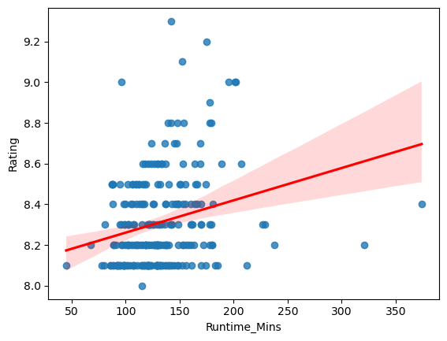

```python
sns.regplot(x='Runtime_Mins', y='Rating', data=df1, line_kws={'color':'red'})
```

### Interpretation:

Often, there is a slight positive correlation. "Epic" movies (longer runtimes) are often perceived as more significant or "grand," which can lead to higher average ratings.

## How has the average rating changed over the decades?

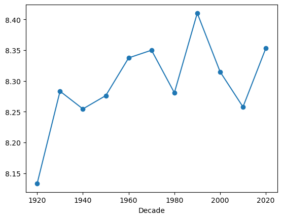

```python
df1.groupby('Decade')['Rating'].mean().plot(marker='o')
```

### Interpretation:

If the line is flat, quality is consistent. If the line drops in recent decades, it might suggest that it takes time for a movie to be recognized as a "true classic" worthy of a high 8.0+ score.

## What is the correlation between 'votes_log' and 'rating'? (Non-Visual)

```python
correlation = df1['Votes_log'].corr(df1['Rating'])
print(f"Correlation: {correlation}")
```

```
Correlation: 0.39115171366414725
```

## Which decade has the highest average engagement (votes)?

```python
print(df1.groupby('Decade')['Votes'].mean().sort_values(ascending=False))
```

```
Decade
1990    1.194547e+06
2000    1.010477e+06
2010    8.752537e+05
1970    7.842081e+05
1980    6.998200e+05
2020    3.607636e+05
1960    3.502106e+05
1950    2.773289e+05
1930    2.710498e+05
1940    2.625963e+05
1920    1.181642e+05
Name: Votes, dtype: float64
```

### Interpretation:

This shows which era of movies modern audiences are actually watching and reviewing. The 1990s often lead here because of hits like The Lion King and Pulp Fiction.

## Rating vs votes

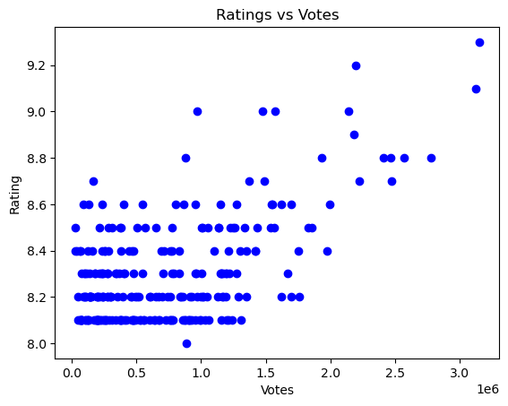

```python
import matplotlib.pyplot as plt

plt.scatter(df1['Votes'], df1['Rating'], color='Blue')
plt.xlabel('Votes')
plt.ylabel('Rating')
plt.title('Ratings vs Votes')
plt.show()
```

## Rating Distribution by Runtime Period

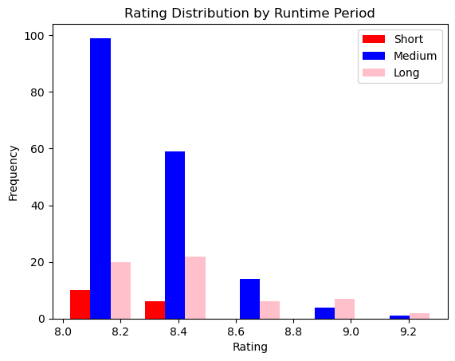

```python
short = df1[df1['Runtime_Period']=='Short']['Rating']
medium = df1[df1['Runtime_Period']=='Medium']['Rating']
long = df1[df1['Runtime_Period']=='Long']['Rating']

plt.hist([short, medium, long], label=['Short','Medium','Long'], color=['red','Blue','pink'], bins=5)
plt.xlabel('Rating')
plt.ylabel('Frequency')
plt.title('Rating Distribution by Runtime Period')
plt.legend()
plt.show()
```

```python
df1.groupby('Content Rating')['Rating'].mean()
```

```
Content Rating
General Audience               8.255556
No Children Under 17           8.300000
Not Rated                      8.276667
Parental Guidance Suggested    8.291892
Parents Strongly Cautioned     8.382353
Restricted                     8.329126
Name: Rating, dtype: float64
```

## Pairwise Relationships: Rank, Runtime, Year'

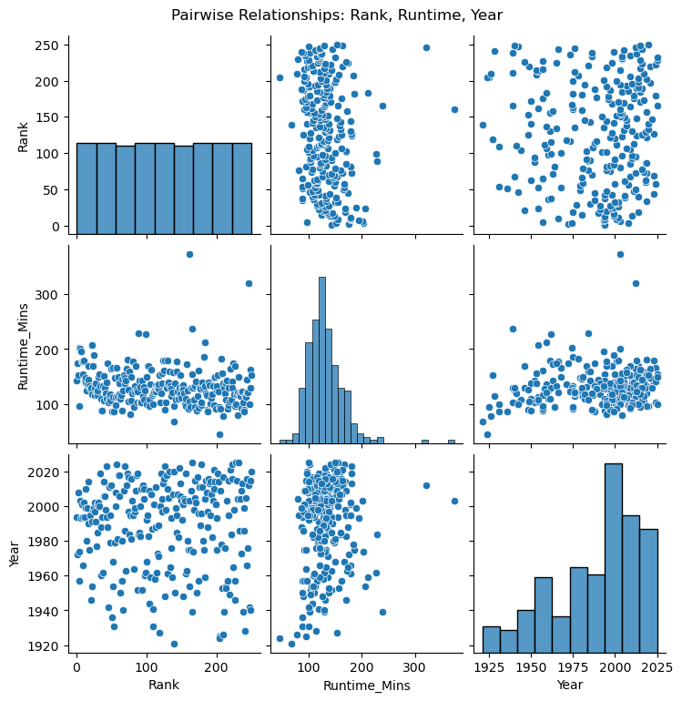

```python
import seaborn as sns
import matplotlib.pyplot as plt

# Select numeric columns
numeric_cols = ['Rank', 'Runtime_Mins', 'Year']

# Pairplot to show scatter plots for all combinations
sns.pairplot(df1[numeric_cols])
plt.suptitle('Pairwise Relationships: Rank, Runtime, Year', y=1.02)
plt.show()
```

## relation between Rank,Runtime_Mins and Year

```python
numeric_cols = ['Rank', 'Runtime_Mins', 'Year']

# Compute correlation matrix
df1[numeric_cols].corr()
```

|  | Rank | Runtime_Mins | Year |
| --- | --- | --- | --- |
| Rank | 1.000000 | -0.145826 | -0.007575 |
| Runtime_Mins | -0.145826 | 1.000000 | 0.137425 |
| Year | -0.007575 | 0.137425 | 1.000000 |

# MULTIVARIATE ANALYSIS

## How do Rating, Votes, and Decade interact?

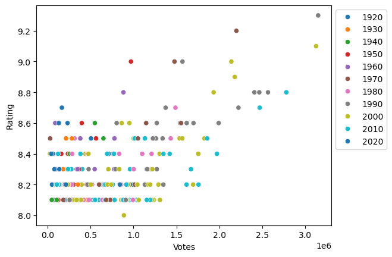

```python
sns.scatterplot(x='Votes', y='Rating', hue='Decade', data=df1, palette='tab10')
plt.legend(bbox_to_anchor=(1, 1), loc='upper left')
```

### Interpretation:

This allows us to see if "Old Classics" (e.g., 1940s) have high ratings despite having lower vote counts compared to "Modern Blockbusters" (e.g., 2010s).

## In which Decade-Runtime combination are the most Votes concentrated? (Intensity Heatmap)

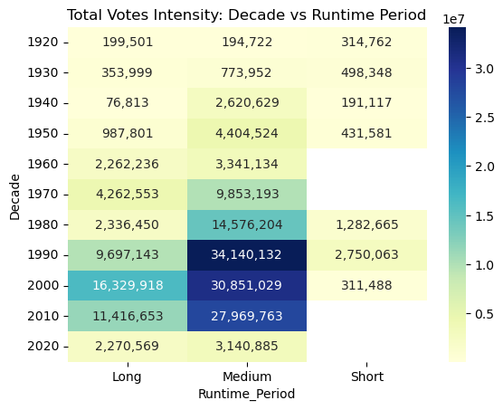

```python
pivot_votes = df1.pivot_table(index='Decade', columns='Runtime_Period', values='Votes', aggfunc='sum')
sns.heatmap(pivot_votes, annot=True, fmt=',.0f', cmap='YlGnBu')
plt.title('Total Votes Intensity: Decade vs Runtime Period')
```

```python
plt.show()
```

## Average Length by Decade and Audience Type

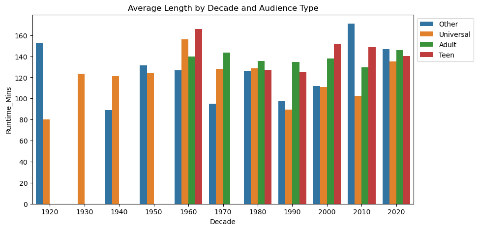

```python
import matplotlib.pyplot as plt
import seaborn as sns

mapping = {
    'General Audience': 'Universal',
    'Parental Guidance Suggested': 'Universal',
    'Parents Strongly Cautioned': 'Teen',
    'Restricted': 'Adult',
    'No Children Under 17': 'Adult',
    'Not Rated': 'Other'
}

df1['Rating'] = df1['Content Rating'].map(mapping).fillna('Other')

plt.figure(figsize=(10, 5))
sns.barplot(data=df1, x='Decade', y='Runtime_Mins', hue='Rating', errorbar=None)
plt.legend(bbox_to_anchor=(1, 1), loc='upper left')
plt.title('Average Length by Decade and Audience Type')
plt.show()
```

## How does the relationship between Votes and Rating change across different Runtime Periods?

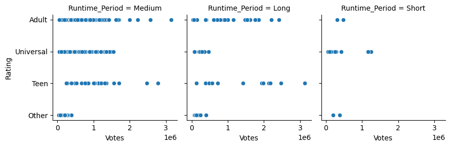

```python
sns.FacetGrid(df1, col="Runtime_Period").map(sns.scatterplot, "Votes", "Rating")
```

# HYPOTHESIS TESTING

## 1. Do long movies have significantly higher IMDb ratings than short movies?

```python
#Two-Sample t-Test

#H₀: Mean rating (long movies) = Mean rating (short movies)

#H₁: Mean rating (long movies) ≠ Mean rating (short movies)

from scipy.stats import ttest_ind

long_movies = df1[df1['Runtime_Mins'] > 130]['Rating']
short_movies = df1[df1['Runtime_Mins'] <= 130]['Rating']

t_stat, p_value = ttest_ind(long_movies, short_movies)
print(p_value)
```

```
1.0820406838973258e-05
```

- Interpretation

Reject H₀ → Runtime length significantly affects ratings Fail → Runtime length does not affect ratings

## 2.When vote counts are high, do certain genres still outperform others in ratings?

```python
#H₀: Under high votes, all genres have equal mean ratings

#H₁: Some genres still outperform

#Statistical Test---ANOVA on high-vote subset

from scipy.stats import f_oneway

high_votes = df1[df1['Votes_log'] >= df1['Votes_log'].quantile(0.75)]

groups = [g['Rating'].values for _, g in high_votes.groupby('Genre')]
f_stat, p_value = f_oneway(*groups)
print("P-value:", p_value)
```

```
P-value: 0.5364732786821986
```

## Interpretation

Reject H₀ → Genre effect persists despite popularity Fail → Popularity neutralizes genre differences

## 3.Do average vote counts differ across genres (Action, Drama, Comedy, etc.)?

```python
#H₀: All genres have the same mean vote counts

#H₁: At least one genre differs
from scipy.stats import f_oneway

groups = [df1['Votes_log'].values for name, g in df1.groupby('Genre') if len(g) > 2]

f_stat, p_value = f_oneway(*groups)
print("P-value:", p_value)
```

```
P-value: 1.0
```

# 4. Is runtime period (Short, Standard, Epic) independent of movie rank quartile (top 25%, mid 50%, bottom 25%)?

```python
import pandas as pd
from scipy.stats import chi2_contingency

# Create quartiles
df1['Rank_quartile'] = pd.qcut(df1['Rank'], 4, labels=['Q1','Q2','Q3','Q4'])

table = pd.crosstab(df1['Runtime_Period'], df1['Rank_quartile'])
chi2, p_value, dof, expected = chi2_contingency(table)
print("P-value:", p_value)
```

```
P-value: 0.3955148125330116
```

```python
import pandas as pd
from scipy.stats import chi2_contingency

# Create a contingency table (frequency counts)
contingency_table = pd.crosstab(df['Genre'], df['Rank'])

# Chi-square test
chi2, p, dof, expected = chi2_contingency(contingency_table)

print(f"Chi-Square Statistic: {chi2}")
print(f"P-value: {p}")
```

```
Chi-Square Statistic: 25999.999999999996
P-value: 0.32300824575836984
```